### Oryginalny wykres

[figure not shown]

You will find more infographics at [Statista](https://www.statista.com/chartoftheday/)

Link do wykresu: https://www.statista.com/chart/23491/share-of-adults-with-diabetes-world-region/

Dane źródłowe, które wykorzystał wykres: https://diabetesatlas.org/idfawp/resource-files/2021/07/IDF_Atlas_10th_Edition_2021.pdf

**Problemy wykresu**

- Na mapie zaznaczono wartość bezwzględną (liczba ludzi chorych na cukrzycę), a nie względną (procent ludzi chorych na cukrzycę). To sprawia, że grupy najludniejsze wypadają najgorzej.
- Kropki, które użyto do zaznaczenia danych są umieszczone w mylących miejscach, co sprawia, że łatwo jest się pomylić przy interpretacji danych.
- Nie ma na wykresie informacji o tym, które tereny należą do której grupy państw. Musiałem informacji szukać w danych źródłowych.
- Można kwestionować dobór wykresu. Jeśli jedynie chodziło o podanie wartości dla różnych grup, to wykres kolumnowy byłby o wiele lepszy. Przy tak małej ilości danych nawet tabelka by sobie dobrze poradziła. Jeśli koniecznie chcemy powiązać dane z punktami na mapie, to użycie źle umieszczonych kropek jest słabym rozwiązaniem.

### Mój wykres

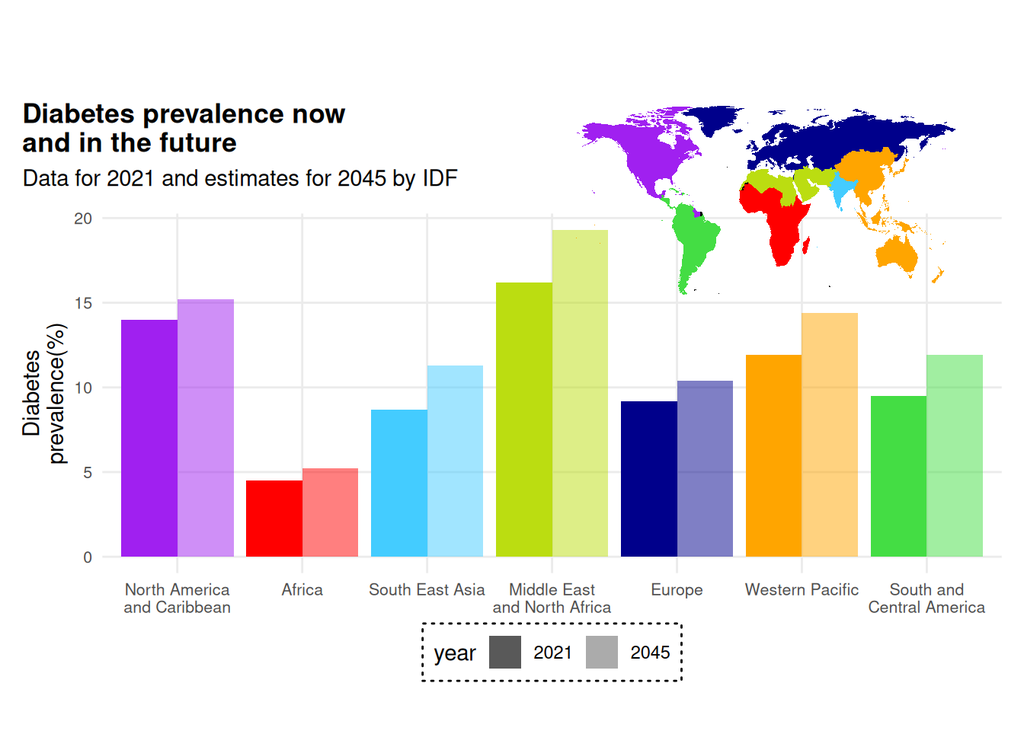

```r
library(dplyr)
library(ggplot2)
library(patchwork)
library(forcats)

WP <- c(
    "American Samoa", "Australia", "Brunei", "Cambodia", "China", "North Korea",
    "Fiji", "French Polynesia", "Guam", "Indonesia", "Japan", "Kiribati", "Laos",
    "Malaysia", "Marshall Islands", "Micronesia", "Mongolia", "Myanmar", "Nauru",
    "New Caledonia", "New Zealand", "Northern Mariana Islands", "Palau", "Papua New Guinea",
    "Philippines", "South Korea", "Samoa", "Singapore", "Solomon Islands", "Taiwan",
    "Thailand", "Timor-Leste", "Tonga", "Vanuatu", "Vietnam"
)

EUR <- c(
    "Albania", "Andorra", "Armenia", "Austria", "Azerbaijan", "Belarus", "Belgium",
    "Bosnia and Herzegovina", "Bulgaria", "Croatia", "Cyprus", "Czech Republic",
    "Denmark", "Estonia", "Faroe Islands", "Finland", "France", "Georgia", "Germany",
    "Greece", "Greenland", "Hungary", "Iceland", "Ireland", "Isle of Man", "Israel",
    "Italy", "Kazakhstan", "Kyrgyzstan", "Latvia", "Liechtenstein", "Lithuania",
    "Luxembourg", "Malta", "Monaco", "Montenegro", "Netherlands", "North Macedonia",
    "Norway", "Poland", "Portugal", "Moldova", "Romania", "Russia", "San Marino",
    "Serbia", "Slovakia", "Slovenia", "Spain", "Sweden", "Switzerland", "Tajikistan",
    "Turkey", "Turkmenistan", "Ukraine", "UK", "Uzbekistan"
)


NAC <- c(
    "Antigua", "Barbuda", "Aruba", "Bahamas", "Barbados", "Belize", "Bermuda", "Canada",
    "Cayman Islands", "Curacao", "Dominica", "Grenada", "Guyana", "Haiti", "Jamaica",
    "Mexico", "Saint Kitts", "Nevis", "Saint Lucia", "Saint Vincent", "Grenadines",
    "Suriname", "Trinidad", "Tobago", "USA", "Virgin Islands"
)

SACA <- c(
    "Argentina", "Bolivia", "Brazil", "Chile", "Colombia", "Costa Rica", "Cuba",
    "Dominican Republic", "Ecuador", "El Salvador", "Guatemala", "Honduras", "Nicaragua",
    "Panama", "Paraguay", "Peru", "Puerto Rico", "Uruguay", "Venezuela"
)

AFR <- c(
    "Angola", "Benin", "Botswana", "Burkina Faso", "Burundi", "Cape Verde", "Cameroon",
    "Central African Republic", "Chad", "Comoros", "Republic of Congo", "Ivory Coast",
    "Democratic Republic of the Congo", "Djibouti", "Equatorial Guinea", "Eritrea",
    "Swaziland", "Ethiopia", "Gabon", "Gambia", "Ghana", "Guinea", "Guinea-Bissau",
    "Kenya", "Lesotho", "Liberia", "Madagascar", "Malawi", "Mali", "Mauritania",
    "Mayotte", "Mozambique", "Namibia", "Niger", "Nigeria", "Rwanda", "Sao Tome and Principe",
    "Senegal", "Seychelles", "Sierra Leone", "Somalia", "South Africa", "South Sudan",
    "Togo", "Uganda", "Tanzania", "Zambia", "Zimbabwe"
)

MENA <- c(
    "Afghanistan", "Algeria", "Bahrain", "Egypt", "Iran", "Iraq", "Jordan", "Kuwait",
    "Lebanon", "Libya", "Morocco", "Oman", "Pakistan", "Qatar", "Saudi Arabia", "Palestine",
    "Sudan", "Syria", "Tunisia", "United Arab Emirates", "Yemen"
)

SEA <- c("Bangladesh", "Bhutan", "India", "Maldives", "Mauritius", "Nepal", "Sri Lanka")

world <- map_data("world") |>
    mutate(
        IDF_region = case_when(
            region %in% NAC ~ "North America and Caribbean", region %in% EUR ~ "Europe",
            region %in% WP ~ "Western Pacific", region %in% SACA ~ "South and Central America",
            region %in% AFR ~ "Africa", region %in% MENA ~ "Middle East and North Africa",
            region %in% SEA ~ "South East Asia", .default = NA
        )
    ) |>
    filter(region != "Antarctica")

map <- world |>
    ggplot(aes(x = long, y = lat, group = group)) +
    coord_fixed(1.3) +
    geom_polygon(aes(fill = IDF_region)) +
    scale_fill_manual(
        values = c("red", "darkblue", "#bbdd11", "purple", "#44dd44", "#44ccff", "orange"),
        na.value = "black"
    ) +
    theme_void() + labs(fill = "Region")


Percentages <- data.frame(
    Region = c(
        "North America\nand Caribbean", "Africa", "South East Asia", "Middle East\nand North Africa",
        "Europe", "Western Pacific", "South and\nCentral America"
    ),
    Y2021 = c(14, 4.5, 8.7, 16.2, 9.2, 11.9, 9.5),
    Y2045 = c(15.2, 5.2, 11.3, 19.3, 10.4, 14.4, 11.9)
)

barplot <- Percentages |>
    tidyr::pivot_longer(!Region, names_to = "year", values_to = "percentage") |>
    mutate(year = substring(year, 2)) |>
    ggplot(
        aes(
            x = fct_inorder(Region),
            y = percentage, fill = Region, alpha = year
        )
    ) +
    geom_col(position = position_dodge()) +
    scale_fill_manual(
        values = c("red", "darkblue", "#bbdd11", "purple", "#44dd44", "#44ccff", "orange"),
        na.value = "black"
    ) +
    scale_alpha_manual(values = c(1, 0.5)) +
    theme_minimal() + theme(
    axis.text = element_text(size = 8),
    axis.title.x = element_blank(), legend.position = "inside", legend.position.inside = c(0.5, -0.22),
    legend.direction = "horizontal", legend.location = "panel", legend.background = element_rect(linetype = 3),
    aspect.ratio = 0.4, panel.grid.minor.y = element_blank()
) +
    labs(y = "Diabetes\nprevalence(%)")



((barplot & guides(fill = "none")) +
    inset_element(
        map & theme(legend.position = "none"),
        0.45, 0.75, 1.05, 1.25, align_to = "full"
    )) +
    plot_annotation(
        title = "Diabetes prevalence now\nand in the future", subtitle = "Data for 2021 and estimates for 2045 by IDF"
    ) &
    theme(plot.title.position = "panel", plot.title = element_text(face = "bold"))
```

**Co poprawiłem**

- Na moim wykresie jest łatwiej porównać dane i są one zebrane razem.
- Mapę wykorzystałem jedynie jako legendę do wykresu, pokazującą dokładnie który region obejmuje które tereny.
- Wykres pokazuje współczynnik zachorowalności na cukrzycę, a nie liczbę cukrzyków, przez co eliminujemy problem z danymi absolutnymi z pierwszego wykresu. Widzimy, że region “Western Pacific”, który na pierwszym wykresie wydawał się najgorszy, jest w rzeczywistości dość przeciętny.